# Data Visualizations

November 6, 2025

Jo Hardin - QSC

# Visualizing the data

## What and why

- Data visualization is the process of transforming raw data into visual formats, like **charts**, **graphs**, or **maps**, to make it easier to understand and interpret
- Communicate results **clearly** and **effectively**
- Supports evidence-based decisions across many fields.

## What is **ggplot2**?

- **ggplot2** is an R package for data visualization
- Encoded functions for numerous different plot types
- Builds plots in layers using `+`

## Basic structure of a ggplot

We will go over each function one at a time.

```r
# General structure
data |>
  ggplot(aes(x = ..., y = ...)) +
  geom_*() +
  labs("label for you plot and axes")
```

## Births in 2015

```r
library(mosaic)
Births2015
```

```
          date births wday year month day_of_year day_of_month day_of_week
1   2015-01-01   8068  Thu 2015     1           1            1           5
2   2015-01-02  10850  Fri 2015     1           2            2           6
3   2015-01-03   8328  Sat 2015     1           3            3           7
4   2015-01-04   7065  Sun 2015     1           4            4           1
5   2015-01-05  11892  Mon 2015     1           5            5           2
6   2015-01-06  12425  Tue 2015     1           6            6           3
7   2015-01-07  12141  Wed 2015     1           7            7           4
8   2015-01-08  12094  Thu 2015     1           8            8           5
9   2015-01-09  11868  Fri 2015     1           9            9           6
10  2015-01-10   8014  Sat 2015     1          10           10           7
11  2015-01-11   7172  Sun 2015     1          11           11           1
12  2015-01-12  11479  Mon 2015     1          12           12           2
13  2015-01-13  11924  Tue 2015     1          13           13           3
14  2015-01-14  12013  Wed 2015     1          14           14           4
```

[output cut: 351 more lines]

Obtained from the National Center for Health Statistics, National Vital Statistics System, Natality, 2015 data.

## How do we make this plot?

Two Questions:

1. What do we want R to do? (What is the goal?)
2. What does R need to know?

## How do we make this plot?

1. Goal: scatterplot = a plot with points
2. What does R need to know?
   - data source: `Births2015`
   - aesthetics:
     - `date -> x`
     - `births -> y`
   - points

## How do we make this plot?

```r
ggplot(data = Births2015,
       aes(x = date, y = births)) +
  geom_point() +
  labs(title = "US Births in 2015")

ggplot() +
  geom_point(data = Births2015,
             aes(x = date, y = births)) +
  labs(title = "US Births in 2015")
```

## Layers: layer 0

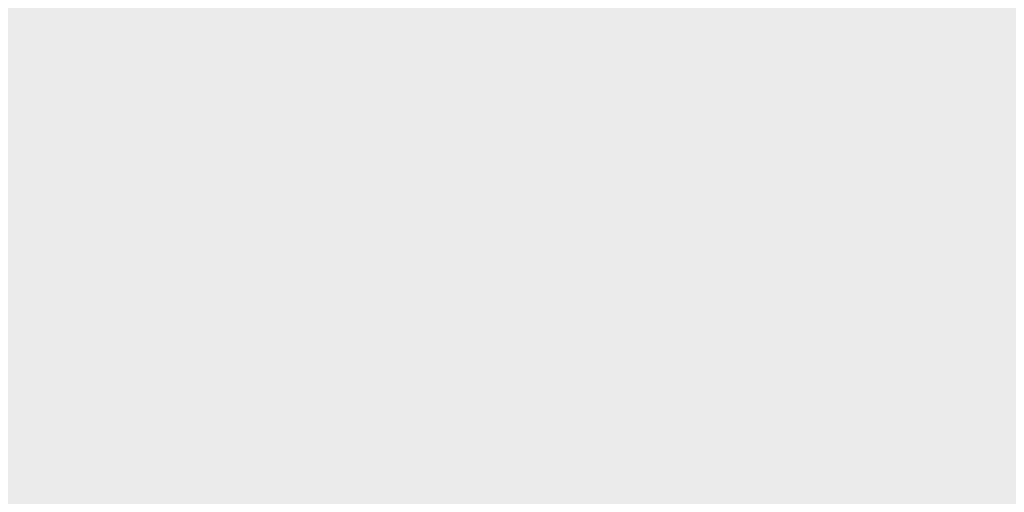

```r
ggplot()
```

## Layers: layer 1

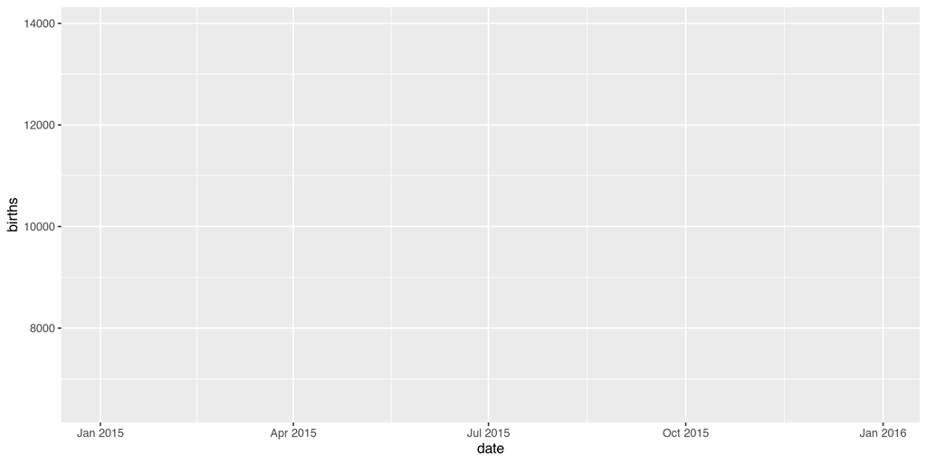

```r
ggplot(data = Births2015,
       aes(x = date, y = births))
```

## Layers: layer 2

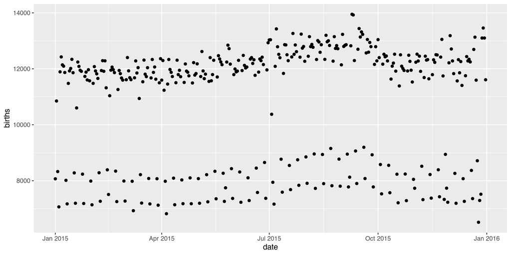

```r
ggplot(data = Births2015,
       aes(x = date, y = births)) +
  geom_point()
```

## Layers: layer 3

```r
ggplot(data = Births2015,
       aes(x = date, y = births)) +
  geom_point() +
  labs(title = "US Births in 2015")
```

[output not shown]

## How do we make this plot?

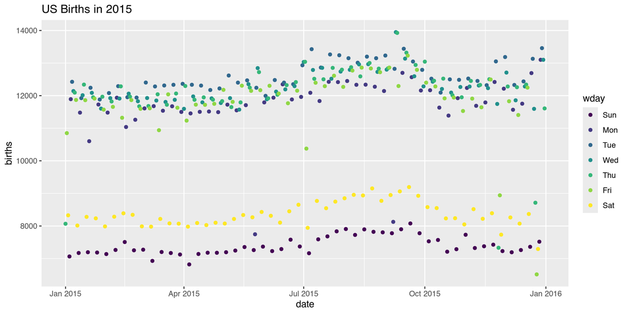

What has changed?

- new aesthetic: mapping color to day of week

## How do we make this plot?

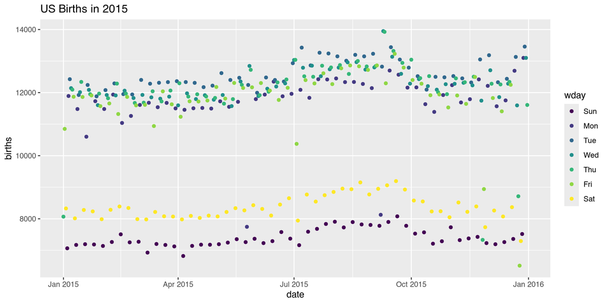

```r
ggplot(data = Births2015,
       aes(x = date,
           y = births,
           color = wday)) +
  geom_point() +
  labs(title = "US Births in 2015")
```

## How do we make this plot?

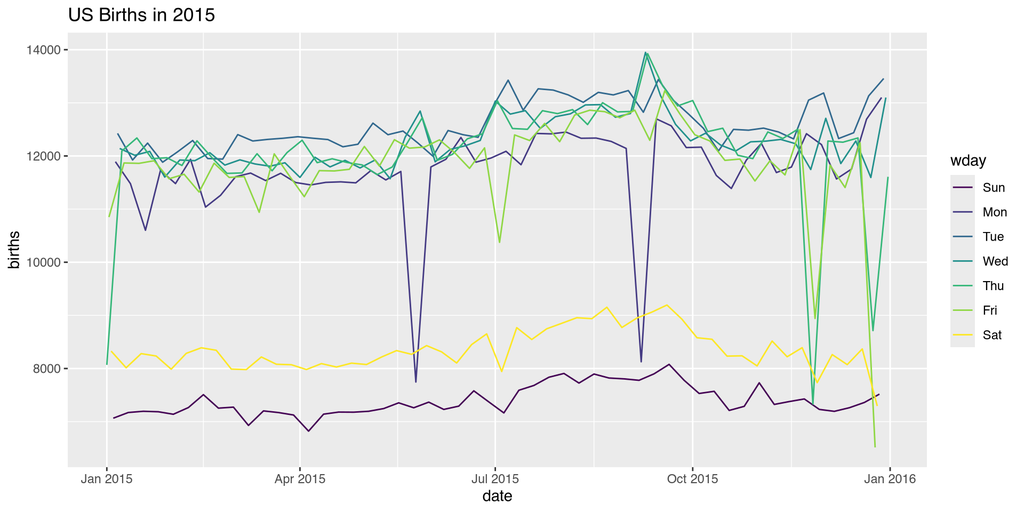

## How do we make this plot?

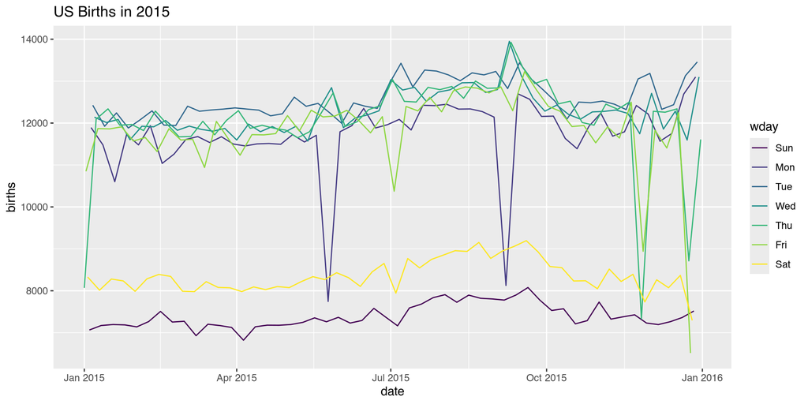

lines instead of dots!

```r
ggplot(data = Births2015,
         aes(x = date,
             y = births,
             color = wday)) +
  geom_line() +
  labs(title = "US Births in 2015")
```

## How do we make this plot?

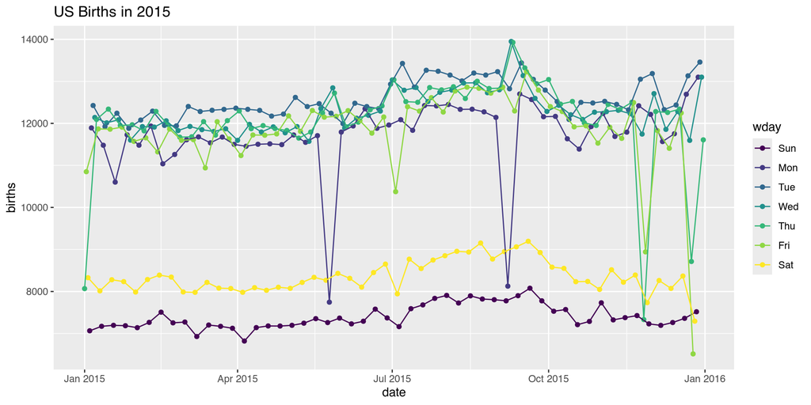

## How do we make this plot?

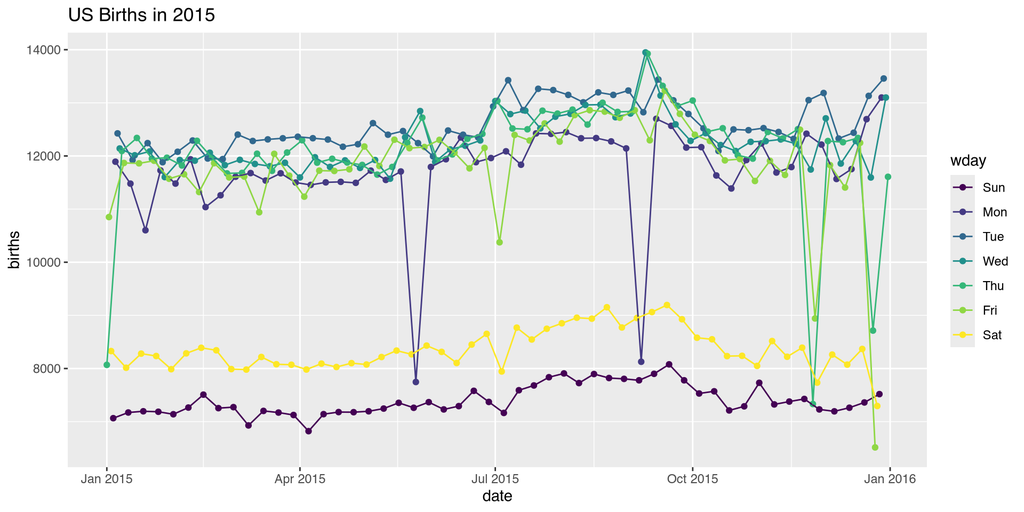

Now there are two **layers**: one with points and one with lines

```r
ggplot(data = Births2015,
       aes(x = date,
           y = births,
           color = wday)) +
  geom_point() +
  geom_line() +
  labs(title = "US Births in 2015")
```

- The layers are placed one on top of the other: the points are *below* and the lines are *above*.
- `data` and `aes` specified in `ggplot()` affect all geoms

## What does this code do?

```r
ggplot(data = Births2015,
       aes(x = date, y = births, color = "navy")) +
  geom_point() +
  labs(title = "US Births in 2015")
```

## What does this code do?

```r
ggplot(data = Births2015,
       aes(x = date, y = births, color = "navy")) +
  geom_point()  +
  labs(title = "US Births in 2015")
```

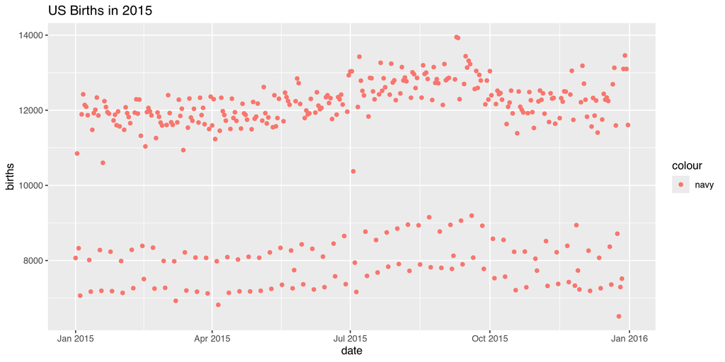

This is *mapping* the color aesthetic to a new variable with only one value (“navy”).  
So all the dots get set to the same color, but it’s not navy.

## Setting vs. Mapping

If we want to *set* the color to be navy for all of the dots, we do it outside the `aes()` designation:

```r
ggplot(data = Births2015,
       aes(x = date, y = births)) +   # map variables
  geom_point(color = "navy")    +   # set attributes
  labs(title = "US Births in 2015")
```

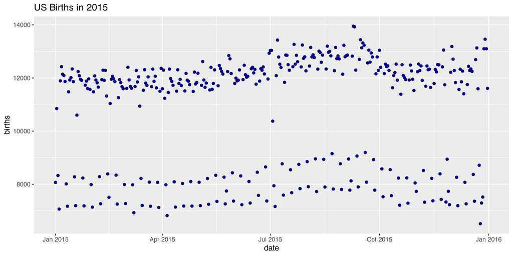

- Note that `color = "navy"` is now outside of the aesthetics list. That’s how `ggplot2` distinguishes between mapping and setting.

## How do we make this plot?

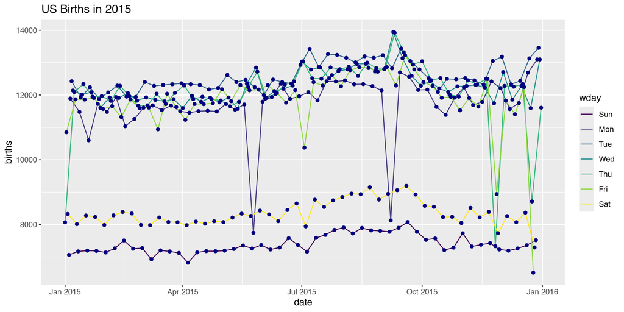

## How do we make this plot?

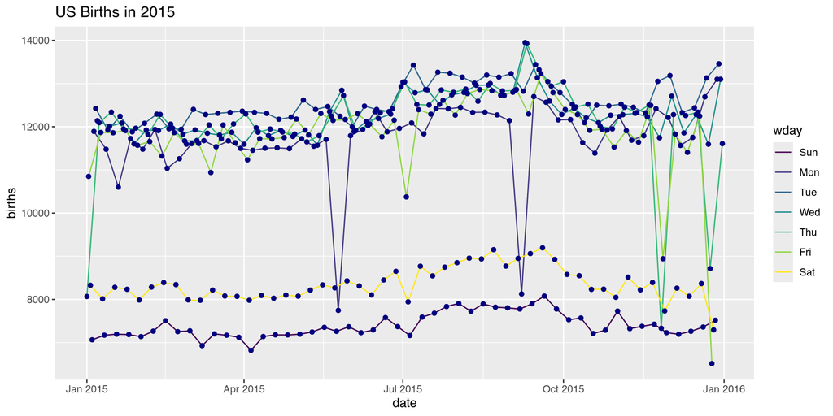

```r
ggplot(data = Births2015,
       aes(x = date,
           y = births)) +
  geom_line(aes(color = wday)) +
  geom_point(color = "navy")  +
  labs(title = "US Births in 2015")
```

- `ggplot()` establishes the default data and aesthetics for the geoms, but each geom may change these defaults.
- good practice: put into `ggplot()` the things that affect all (or most) of the layers; rest in `geom_XXXX()`

## Setting vs. Mapping (again)

Information gets passed to the plot via:

1. `map` the **variable** information inside the aes (aesthetic) command
2. `set` the **non-variable** information outside the aes (aesthetic) command

## `geom_*()` types

```r
apropos("^geom_")
```

```
 [1] "geom_abline"            "geom_area"              "geom_ash"
 [4] "geom_bar"               "geom_bin_2d"            "geom_bin2d"
 [7] "geom_blank"             "geom_boxplot"           "geom_col"
[10] "geom_contour"           "geom_contour_filled"    "geom_count"
[13] "geom_crossbar"          "geom_curve"             "geom_density"
[16] "geom_density_2d"        "geom_density_2d_filled" "geom_density2d"
[19] "geom_density2d_filled"  "geom_dotplot"           "geom_errorbar"
[22] "geom_errorbarh"         "geom_freqpoly"          "geom_function"
[25] "geom_hex"               "geom_histogram"         "geom_hline"
[28] "geom_jitter"            "geom_label"             "geom_line"
[31] "geom_linerange"         "geom_lm"                "geom_map"
[34] "geom_path"              "geom_point"             "geom_pointrange"
[37] "geom_polygon"           "geom_qq"                "geom_qq_line"
[40] "geom_quantile"          "geom_rangeframe"        "geom_raster"
[43] "geom_rect"              "geom_ribbon"            "geom_rug"
[46] "geom_segment"           "geom_sf"                "geom_sf_label"
[49] "geom_sf_text"           "geom_smooth"            "geom_spline"
[52] "geom_spoke"             "geom_step"              "geom_text"
[55] "geom_tile"              "geom_tufteboxplot"      "geom_violin"
[58] "geom_vline"
```

## `geom_*()` pics

[figure not shown]

https://ggplot2.tidyverse.org/

## `geom_*()` help

help pages will tell you their aesthetics, default stats, etc.

```r
?geom_area             # for example
```

## Let’s try `geom_area`

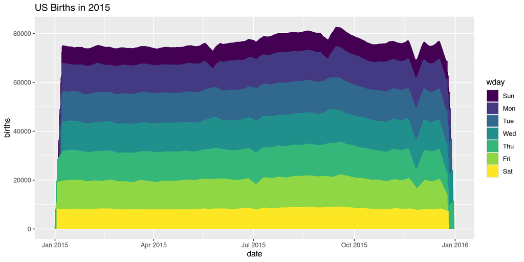

```r
ggplot(data = Births2015,
       aes(x = date,
           y = births,
           fill = wday)) +
  geom_area() +
  labs(title = "US Births in 2015")
```

## Let’s try `geom_area`

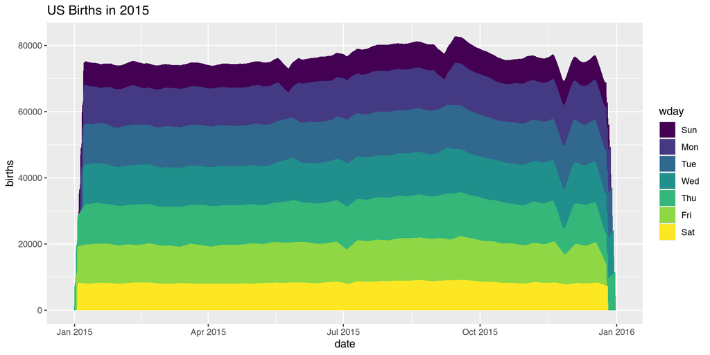

```r
ggplot(data = Births2015,
       aes(x = date, y = births, fill = wday)) +
  geom_area() +
  labs(title = "US Births in 2015")
```

… not a good plot

- overplotting is hiding much of the data
- extending y-axis to 0 may or may not be desirable.

## Side note: what makes a plot good?

Most (all?) graphics are intended to help us make comparisons

- How does something change over time?
- Do my treatments matter? How much?
- Do treatment and control respond the same way?

**Key plot metric**

Does my plot make the comparisons I am interested in:

- easily, and
- accurately?

# TidyTuesday

[figure not shown]

Image credit: https://github.com/rfordatascience/tidytuesday

## TidyTuesday data

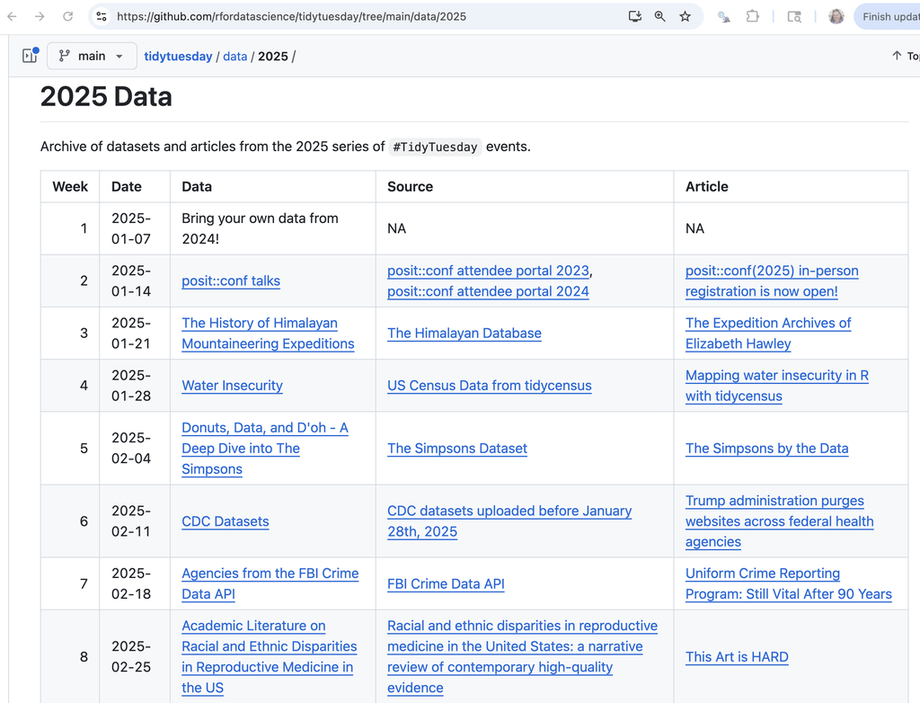

Image credit: https://github.com/rfordatascience/tidytuesday/tree/main/data/2025

## TidyTuesday at Pomona

- Every Tuesday from 11-1pm
- Estella 2131
- Open to beginners… but come with a curious mindset and ask lots of questions!
- The task will be to make a graphic (usually)

## Past TidyTuesday

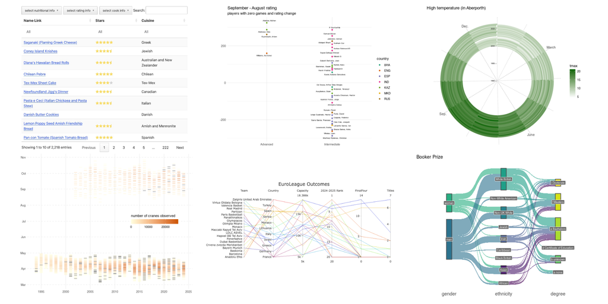

image credit: https://hardin47.github.io/TidyTuesday/

# Data science minor at Pomona

## Courses

- introduction to statistics
- computer science
- linear algebra
- foundations of data science
- ethics in data science
- one upper division course
- capstone project (0.5 units, fall senior year)

## Important considerations

- You **must** be done with the 5 lower division courses by the end of your junior spring.
- You **must** have a faculty member in a discipline outside of mathematics / statistics / computer science to supervise the capstone project.
- Check out these [FAQ: https://www.pomona.edu/academics/departments/data-science/frequently-asked-questions](https://www.pomona.edu/academics/departments/data-science/frequently-asked-questions).

# Lots more **ggplot2**

## Time for some different data

HELPrct: Health Evaluation and Linkage to Primary care randomized clinical trial. Subjects admitted for treatment for addiction to one of three substances.

```r
head(HELPrct)
```

| age | anysubstatus | anysub | cesd | d1 | daysanysub | dayslink | drugrisk | e2b | female | sex | g1b | homeless | i1 | i2 | id | indtot | linkstatus | link | mcs | pcs | pss_fr | racegrp | satreat | sexrisk | substance | treat | avg_drinks | max_drinks | hospitalizations |
| --- | --- | --- | --- | --- | --- | --- | --- | --- | --- | --- | --- | --- | --- | --- | --- | --- | --- | --- | --- | --- | --- | --- | --- | --- | --- | --- | --- | --- | --- |
| 37 | 1 | yes | 49 | 3 | 177 | 225 | 0 | NA | 0 | male | yes | housed | 13 | 26 | 1 | 39 | 1 | yes | 25.111990 | 58.41369 | 0 | black | no | 4 | cocaine | yes | 13 | 26 | 3 |
| 37 | 1 | yes | 30 | 22 | 2 | NA | 0 | NA | 0 | male | yes | homeless | 56 | 62 | 2 | 43 | NA | NA | 26.670307 | 36.03694 | 1 | white | no | 7 | alcohol | yes | 56 | 62 | 22 |
| 26 | 1 | yes | 39 | 0 | 3 | 365 | 20 | NA | 0 | male | no | housed | 0 | 0 | 3 | 41 | 0 | no | 6.762923 | 74.80633 | 13 | black | no | 2 | heroin | no | 0 | 0 | 0 |
| 39 | 1 | yes | 15 | 2 | 189 | 343 | 0 | 1 | 1 | female | no | housed | 5 | 5 | 4 | 28 | 0 | no | 43.967880 | 61.93168 | 11 | white | yes | 4 | heroin | no | 5 | 5 | 2 |
| 32 | 1 | yes | 39 | 12 | 2 | 57 | 0 | 1 | 0 | male | no | homeless | 10 | 13 | 5 | 38 | 1 | yes | 21.675755 | 37.34558 | 10 | black | no | 6 | cocaine | no | 10 | 13 | 12 |
| 47 | 1 | yes | 6 | 1 | 31 | 365 | 0 | NA | 1 | female | no | housed | 4 | 4 | 6 | 29 | 0 | no | 55.508991 | 46.47521 | 5 | black | no | 5 | cocaine | yes | 4 | 4 | 1 |

## Who are the people in the study?

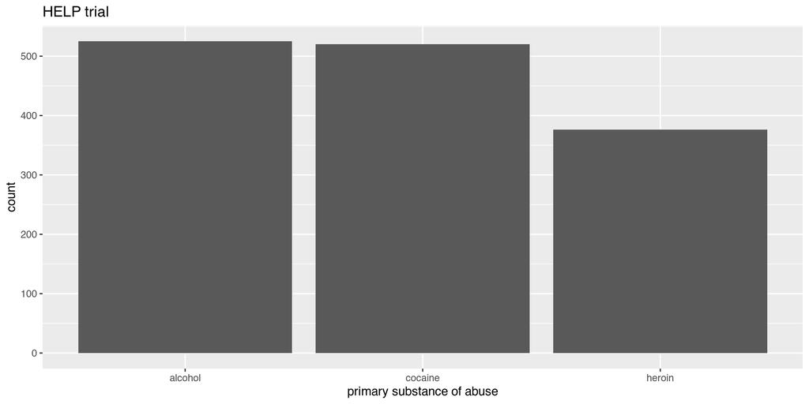

```r
ggplot(data = HELP_data,
       aes(x = substance)) +
  geom_bar() +
  labs(title = "HELP trial")
```

- Hmm. What’s up with `y`?

## Who are the people in the study?

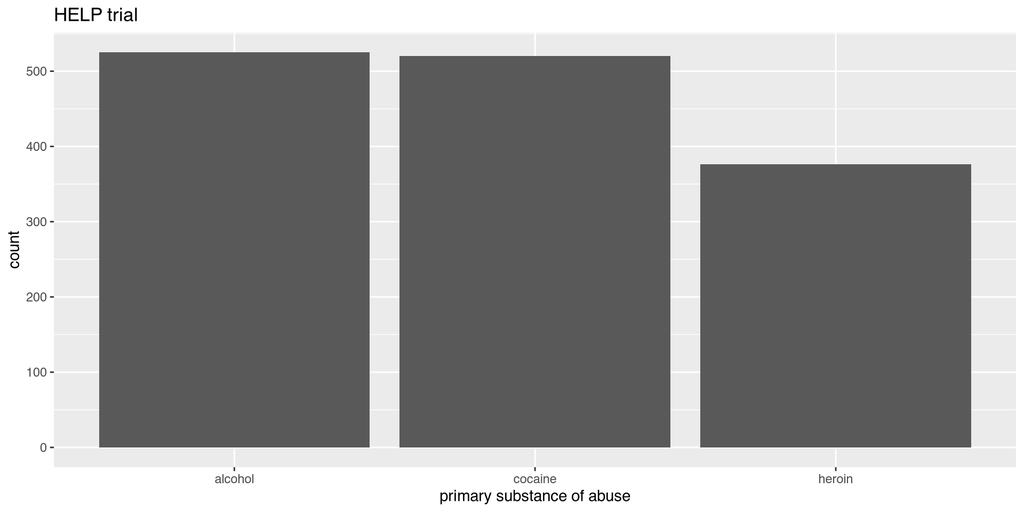

```r
ggplot(data = HELP_data,
       aes(x = substance)) +
  geom_bar() +
  labs(title = "HELP trial")
```

## Who are the people in the study?

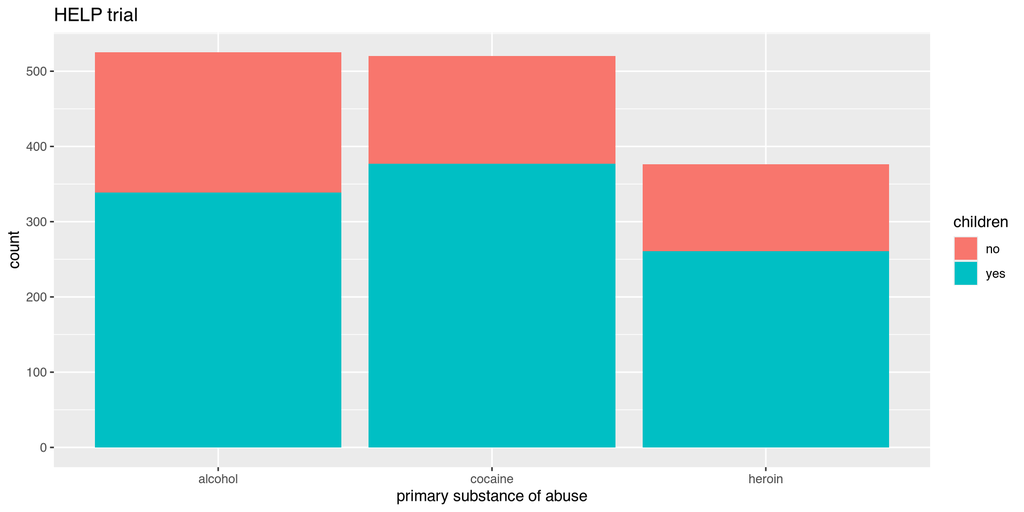

```r
ggplot(data = HELP_data,
       aes(x = substance,
           fill = children)) +
  geom_bar() +
  labs(title = "HELP trial")
```

## Who are the people in the study?

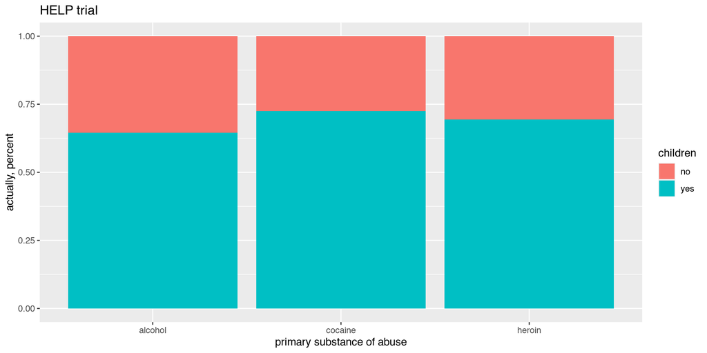

```r
ggplot(HELP_data,
       aes(x = substance,
           fill = children)) +
  geom_bar(position = "fill") +
  labs(title = "HELP trial",
       y = "actually, percent")
```

## How old are people in the HELP study?

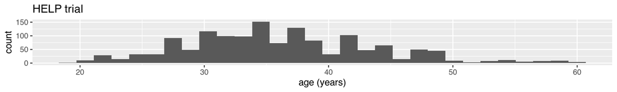

```r
ggplot(data = HELP_data,
       aes(x = age)) +
  geom_histogram() +
  labs(title = "HELP trial")
```

- `stat_bin`: Histograms are not mapping the raw data but binned data.  
  `stat_bin()` performs the data transformation.
- `binwidth`: a default binwidth has been selected, but we should really choose our own.

## Setting the binwidth manually

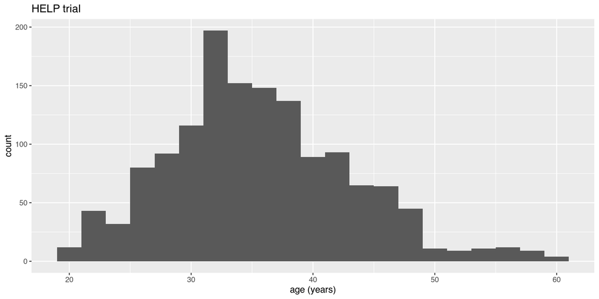

```r
ggplot(data = HELP_data,
       aes(x = age)) +
  geom_histogram(binwidth = 2) +
  labs(title = "HELP trial")
```

## How old are people in the HELP study? – Other geoms

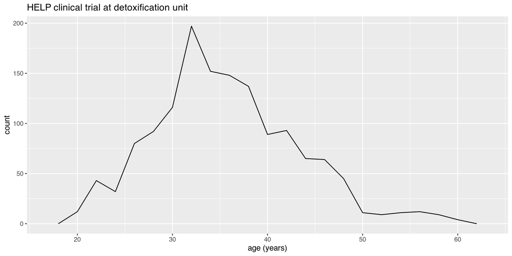

```r
ggplot(data = HELP_data,
       aes(x = age)) +
  geom_freqpoly(binwidth = 2) +
  labs(title = "HELP clinical trial at detoxification unit")
```

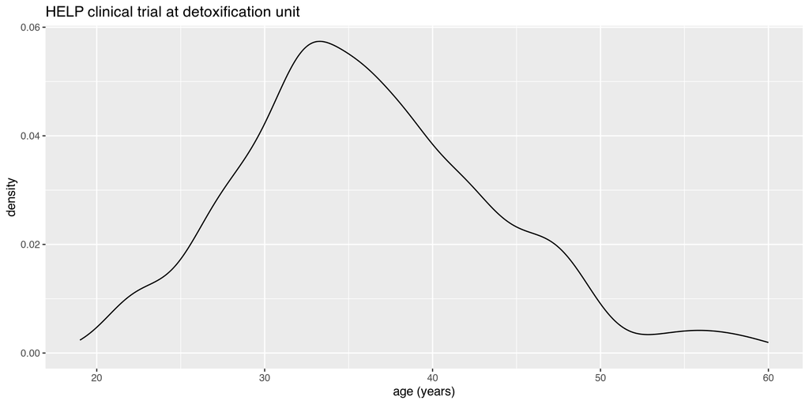

```r
ggplot(data = HELP_data,
       aes(x = age)) +
  geom_density() +
  labs(title = "HELP clinical trial at detoxification unit")
```

## Selecting stat and geom manually

Every geom comes with a default stat

- for simple cases, the stat is `stat_identity()` which does nothing
- we can mix and match geoms and stats however we like

```r
ggplot(data = HELP_data,
       aes(x = age)) +
  geom_line(stat = "density") +
  labs(title = "HELP clinical trial at detoxification unit")
```

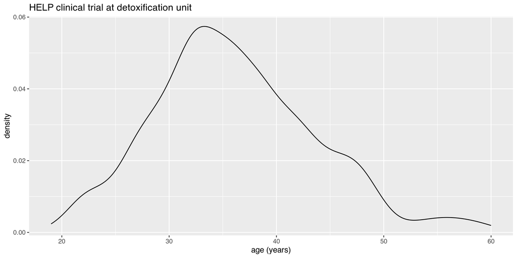

## Selecting stat and geom manually

Every stat comes with a default geom, every geom with a default stat

- we can specify stats instead of geom, if we prefer
- we can mix and match geoms and stats however we like

```r
ggplot(data = HELP_data,
       aes(x = age)) +
  stat_density(geom = "line") +
  labs(title = "HELP clinical trial at detoxification unit")
```

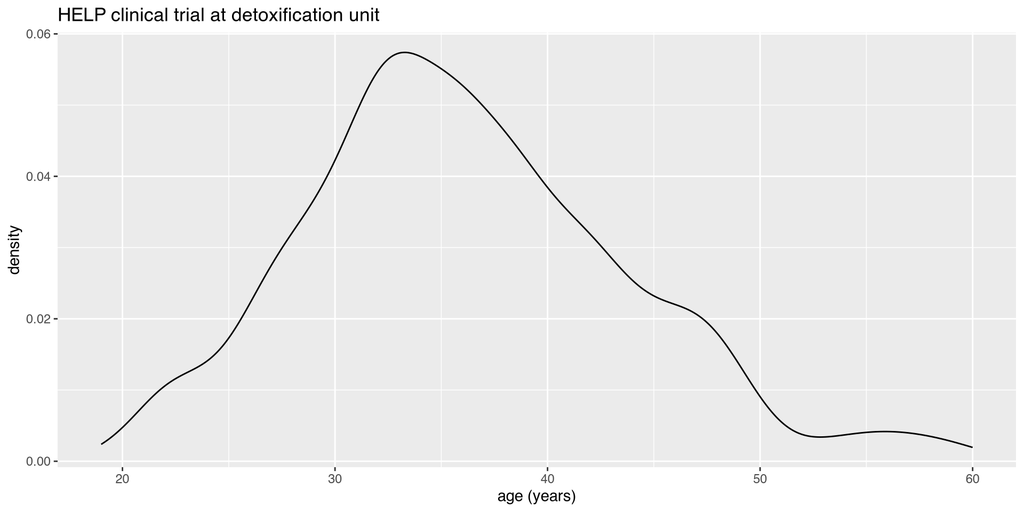

## More combinations

```r
ggplot(data = HELP_data,
       aes(x = age)) +
  geom_point(stat = "bin", binwidth = 3) +
  geom_line(stat = "bin", binwidth = 3)  +
  labs(title = "HELP clinical trial at detoxification unit")
```

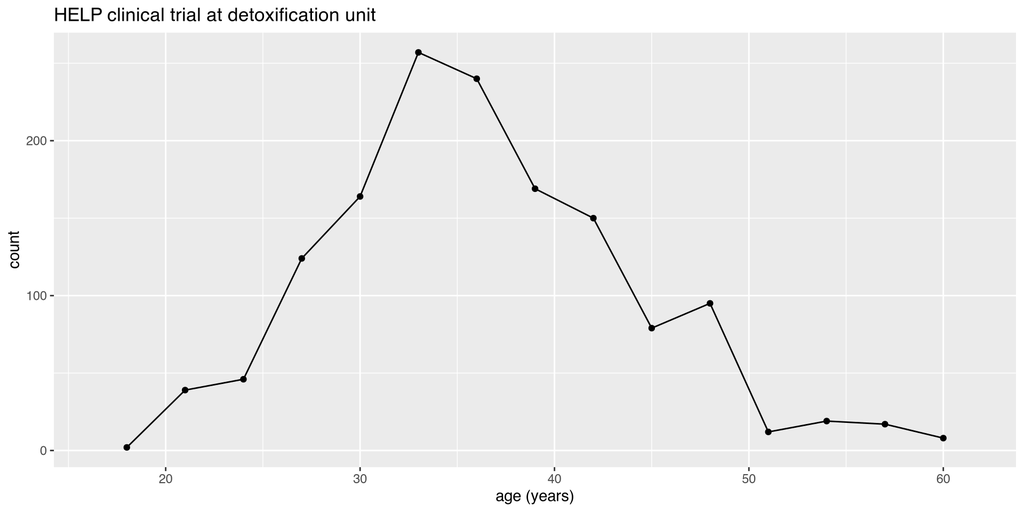

## More combinations

```r
ggplot(data = HELP_data,
       aes(x = age)) +
  geom_area(stat = "bin", binwidth = 3)  +
  labs(title = "HELP clinical trial at detoxification unit")
```

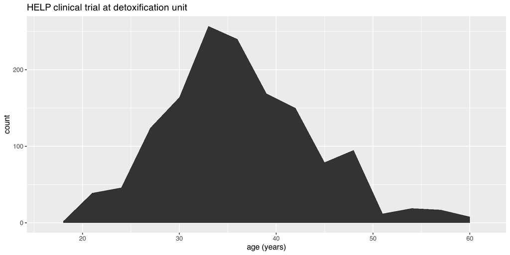